# <font color="red">Lecture 4 – Review of Probability and Statistics</font>

# Density `\(\rightarrow\)` probability requires integration

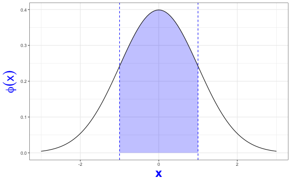

# Statistical Inference

* The **parameter space** is the set of all possible values for the parameter

* One major goal: to "figure out" (i.e. estimate) the **parameter values**
  - i.e. *"fit the model to the data"*

* The model is a representation that (we hope) approximates the data and (more importantly) the population that the data were sampled from

* We can then use this model for:
  - hypothesis testing
  - prediction
  - simulation

# Statistical Inference

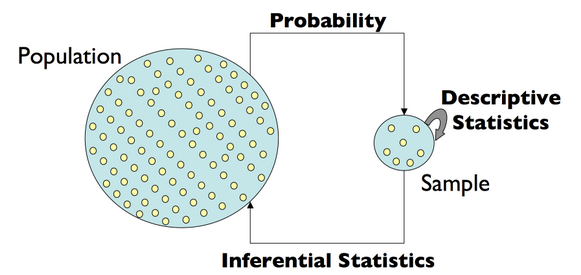

# IID

* A requirement (assumption) in many settings is that the data are IID: **I**ndependent and **I**dentically **D**istributed

* **Identically Distributed**: a set of observations (events) are from the same population (i.e. they have the same underlying probability distribution)

- e.g. a t-test assumes that under the null, all observations come from the same normal distribution

* **Independent**: all samples satisfy the condition `$$P(A,B) = P(A)P(B)$$` where `\(A\)` and `\(B\)` are events

- i.e. the joint probability is the product of the individual event probabilities
  - The above statement is for two events, but the same definition applies for any number of events
(without loss of generality for any number of events)

# Violations of independence

* Experimental design is in part about trying to avoid unwanted dependence

* Example of design with violation of independence assumption:

> Height measurements of individuals sampled from *related* females in a tall family

# Parameters of the normal distribution

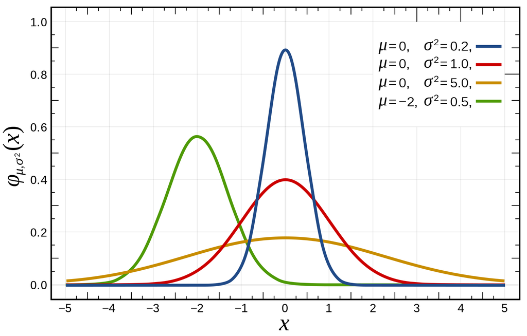

`$$f(x|\mu,\sigma^2) = \frac{1}{\sqrt{2\pi}\sigma}e^{-\frac{(x-\mu)^2}{2\sigma^2}}$$`
* Mean `\(=\mu\)`

* Standard Deviation `\(=\sigma\)`

* For convenience, we write `\(N(\mu, \sigma^2)\)`

* Population parameters are unknown

# Parameter estimation

<big>

* **Estimator**: A function (or rule) used to estimate a parameter of interest

* **Estimate**: A particular realization (value) of an estimator

# Estimators for normally distributed data

* If we are given a sample of `\(n\)` observations from a normally distributed population, how do we estimate the parameter values `\(\mu\)` and `\(\sigma\)`?

* Recall `\(\mu\)` is the mean and `\(\sigma\)` the standard deviation of the distribution

`$$\hat{\mu} = \bar{x} = \frac{x_1 + x_2 + ... + x_n}{n} =  \frac{1}{n} \sum_{i=1}^n x_i$$`

`$$\hat{\sigma} = s = \sqrt{\frac{\sum_{i=1}^n(x_i - \bar{x})^2}{n-1}}$$`

# Estimators vs Parameters

|   | Estimators | Parameters |
| ---- | :---------: | :----------: |
| Summarize | Sample | Population (ground truth) |
| Value | Computed from data | Unknown |
| Notation | `\(\hat{\theta}\)` | `\(\theta\)` |

# Normal **Mean**: Estimator vs Parameter

|   | Estimator | Parameter |
| ---- | :---------: | :----------: |
| Summarizes |  Sample/data | Population (ground truth) |
| Value | `\(\bar{x}=\frac{1}{n} \sum_{i=1}^n x_i\)` | Unknown |
| Notation | `\(\hat{\mu}\)` | `\(\mu\)` |

# Normal **Standard Deviation**: Estimator vs Parameter

|   | Estimator | Parameter |
| ---- | :---------: | :----------: |
| Summarizes |  Sample/data | Population (ground truth) |
| Value | `\(s=\sqrt{\frac{\sum_{i=1}^n(x_i - \bar{x})^2}{n-1}}\)` | Unknown |
| Notation | `\(\hat{\sigma}\)` | `\(\sigma\)` |

# Estimator for normally distributed data

* Let's say we collected a **sample** from a population we assume to be normal

* We estimate the mean `\(\large \hat{\mu}=\bar{x}\)`

* How good is the estimate?

* The answer depends on:

- sample size

- variability of the population

# Sampling distribution

* **Statistic**: any quantity computed from values in a sample

* Any function (or statistic) of a sample (data) is a random variable

* Thus, any statistic (because it is random) has a probability distribution function `\(\rightarrow\)` specifically, we call this the *sampling distribution*

* Example: the sampling distribution of the mean

# Sampling distribution of the mean

The sample mean `\(\large \bar{x}\)` is an RV, so it has associated probability or sampling distribution

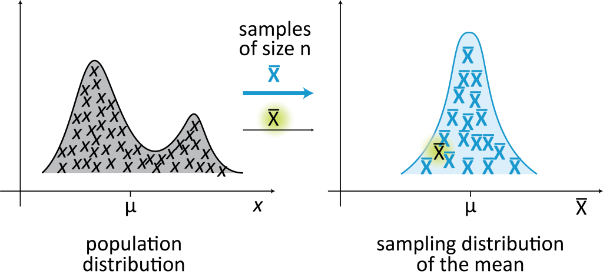

<a href="http://www.incertitudes.fr/book.pdf" style="color:grey;">Image source: incertitudes.fr/book.pdf</a>

# Central Limit Theorem (CLT)

By the *Central Limit Theorem (CLT)*, we know that the sampling distribution of the mean is Normal:
* with mean `\(\mu_{\bar{X}} = \mu\)` and standard deviation `\(\sigma_{\bar{X}} = \frac{\sigma}{\sqrt{n}}\)`

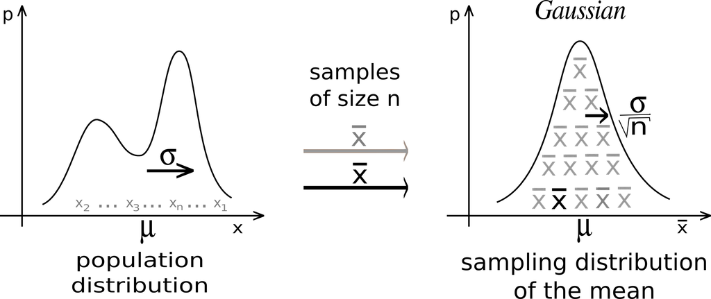

<a href="http://www.incertitudes.fr/book.pdf" style="color:grey;">Image source: incertitudes.fr/book.pdf</a>

# <center> ⚠️ Standard deviation vs Standard error ⚠️

<big>

* The sampling distribution of the mean (by CLT): `$$\bar{X} \sim N(\mu, \frac{\sigma^2}{n})$$`

* The *standard error* of the mean is `\(\frac{\sigma}{\sqrt{n}}\)`

* The *standard deviation* of `\(X\)` is `\(\sigma\)`

## Estimation of parameters of the sampling distribution of the mean

Just as we estimated `\(\mu\)` and `\(\sigma\)` before, we can estimate `\(\mu_{\bar{X}}\)` and `\(\sigma_{\bar{X}}\)`

- `\(\hat{\mu}_{\bar{X}} = \hat{\mu} = \bar{x}\)`

- `\(\hat{\sigma}_{\bar{X}} = \frac{\hat{\sigma}}{\sqrt{n}} = \frac{s}{\sqrt{n}}\)`

# Standard error of the mean

`$$\large\hat{\sigma}_{\bar{X}} = \frac{\hat{\sigma}}{\sqrt{n}} = \frac{s}{\sqrt{n}}$$`
* The standard error (SE) of the mean reflects uncertainty about the value of the population mean `\(\large\mu\)`

* The CLT assumes a 'large enough' sample:

- when the sample size is ~30 or more, the normal distribution is a good approximation for the sampling distribution of the mean

- for smaller samples, the SE `\(\large\frac{s}{\sqrt{n}}\)` is an underestimate

# CLT applies to any population (regardless of distribution)

Let `\(\normalsize X_1, X_2, ..., X_n\)` be a random sample from a population with a non-normal distribution. If the sample size `\(\normalsize n\)` is sufficiently large, then the sampling distribution of the mean will be approximately normal: `\(\normalsize \bar{X} \sim N(\mu, \frac{\sigma^2}{n})\)`

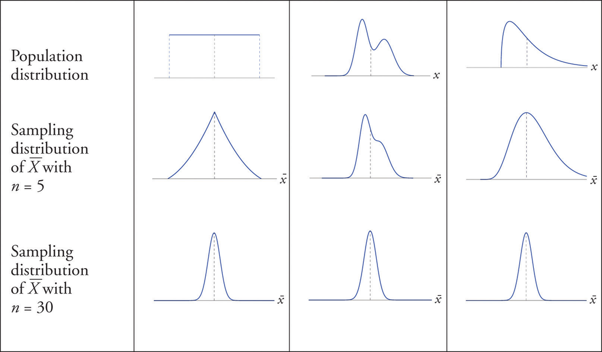

[Image source: saylordotorg.github.io/text_introductory-statistics](https://saylordotorg.github.io/text_introductory-statistics/s10-02-the-sampling-distribution-of-t.html)

# Illustration (n = 3)

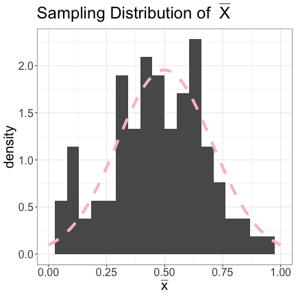

On right: dashed pink line is `\(N(\mu, \sigma^2/n)\)`

# Illustration (n = 10)

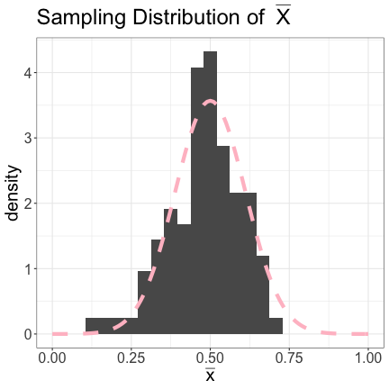

On right: dashed pink line is `\(N(\mu, \sigma^2/n)\)`

# Illustration (n = 30)

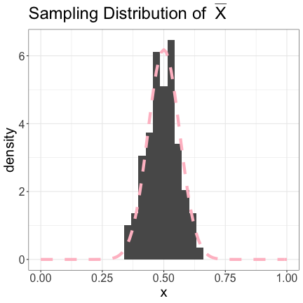

On right: dashed pink line is `\(N(\mu, \sigma^2/n)\)`

# Illustration (n = 100)

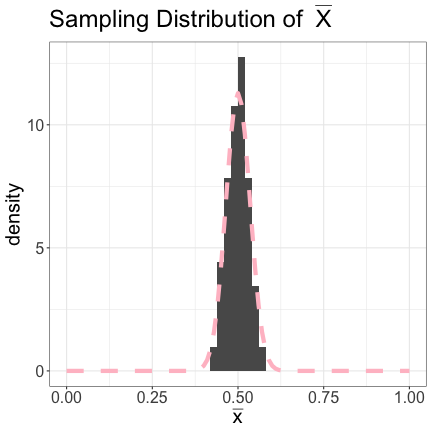

On right: dashed pink line is `\(N(\mu, \sigma^2/n)\)`

# Hypothesis Testing

* **Hypothesis:** A *testable (falsifiable)* idea for explaining a phenomenon

* **Statistical hypothesis:** A hypothesis that is testable on the basis of observing a process that is modeled via a set of random variables

* **Hypothesis Testing:** A formal procedure for determining whether to *accept* or *reject* a statistical hypothesis

* Requires comparing two hypotheses:

- `\(H_0\)`: null hypothesis

- `\(H_A\)` or `\(H_1\)`: alternative hypothesis

# Hypothesis Testing: motivating example

* The expression level of gene `\(\normalsize g\)` is measured in `\(\normalsize n\)` patients with disease (e.g. cancer), and `\(\normalsize m\)` healthy (control) individuals:
  - `\(\normalsize z_1, z_2, ..., z_n\)` and `\(\normalsize y_1, y_2, ..., y_m\)`

* Is gene `\(\normalsize g\)` is differentially expressed in cancer vs healthy samples?
  - `\(\normalsize H_0: \mu_Z = \mu_Y\)`
  - `\(\normalsize H_A: \mu_Z \neq \mu_Y\)`

* In this setting, hypothesis testing allows us to determine whether observed differences between groups in our data are *significant*

# Steps in Hypothesis Testing

<big>

1. Formulate your hypothesis as a statistical hypothesis

2. Define a test statistic (RV) that corresponds to the question. You typically know the expected distribution of the test statistic *under the null*

3. Compute the p-value associated with the observed test statistic under the null distribution `\(\normalsize p(t | H_0)\)`

# Motivating example (cancer vs healthy gene expression)

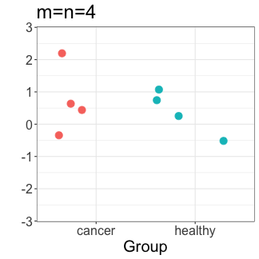

# Motivating example (cancer vs healthy gene expression)

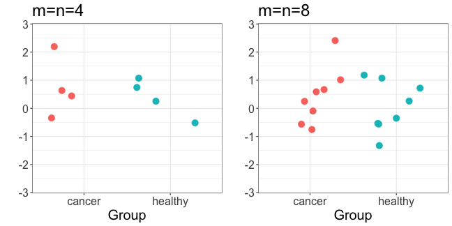

# Motivating example (cancer vs healthy gene expression)

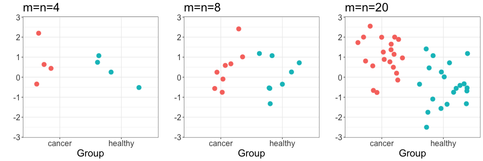

All three samples drawn from iid Normal distributions with equal variance and `\(\mu_Z-\mu_Y=1\)`

# Is there a **significant** difference between the two means?

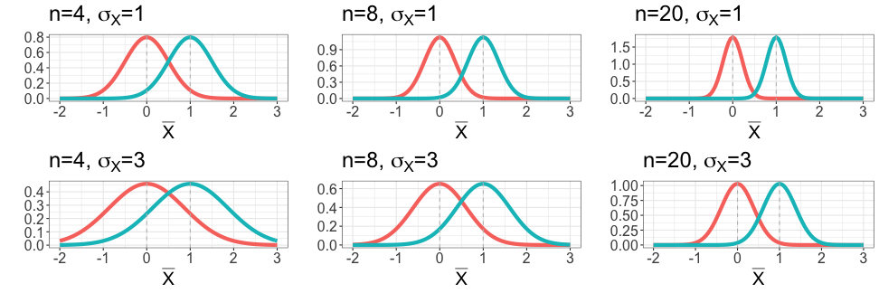

* Mean difference needs to be put into context of the *spread (standard deviation)*

* Also depends on the sample size

# t-statistic / t-test

* Standard error estimate for the difference in means:

`$$SE_{\bar{z}-\bar{y}} = s_p \sqrt{\frac{1}{n} + \frac{1}{m}} \text{ , where  } s_p^2 = \frac{s^2_z + s^2_y}{(n-1) + (m-1)}$$`

# t-test

* From the theory, we know the distribution of our test statistic, if we are willing to make some assumptions

* If we assume:

- Z and Y are normally distributed

- Z and Y have equal variance

Then our t-statistic follows a t distribution with m+n-2 degrees of freedom `$$t \sim t_{n+m-2}$$`

# t distribution

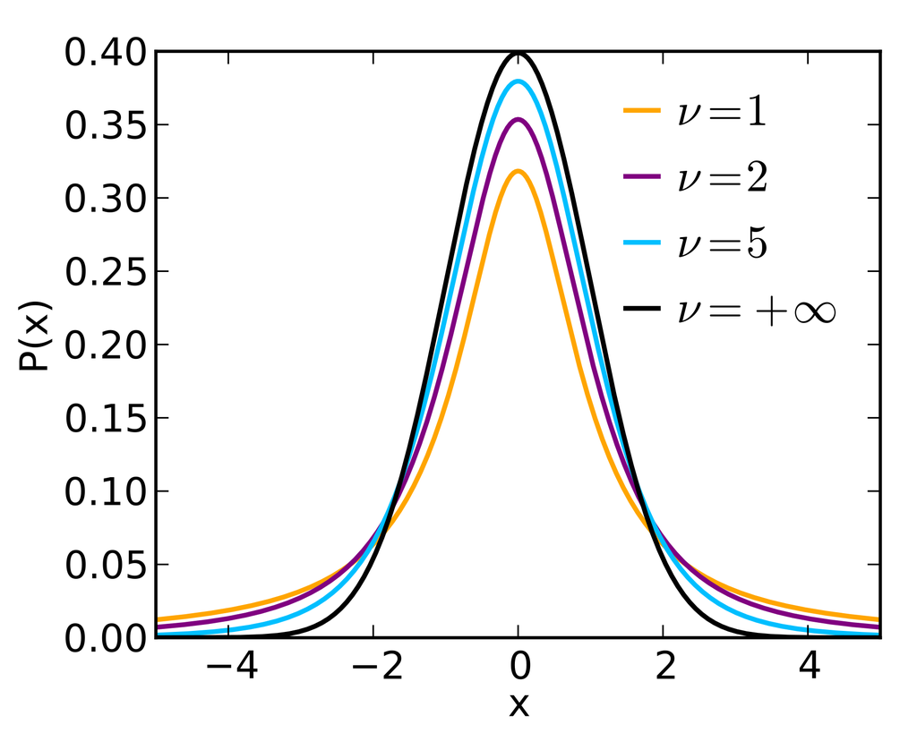

* t statistic value tells us how extreme our observed data is relative to the null

* obtain p-value by computing area to the left and/or right of the t statistic (one-sided vs two-sided)

# Summary

* Random variables are variables that have an associated probability distribution

* Any statistic of sampled data is an RV, and hence has an associated probability distribution

* The CLT gives us the sampling distribution of the mean

* Hypothesis testing gives us a framework to assess a statistical hypothesis under the null